# DAT200_Week9_Assignment_Zoe Jin

```python
import pandas as pd
import numpy as np
import matplotlib.pyplot as plt
from sklearn.cluster import KMeans
from sklearn.preprocessing import StandardScaler
```

```python
original_data = pd.read_csv('Wholesale customers data.csv')
original_data.head()
```

|  | Channel | Region | Fresh | Milk | Grocery | Frozen | Detergents_Paper | Delicassen |
| --- | --- | --- | --- | --- | --- | --- | --- | --- |
| 0 | 2 | 3 | 12669 | 9656 | 7561 | 214 | 2674 | 1338 |
| 1 | 2 | 3 | 7057 | 9810 | 9568 | 1762 | 3293 | 1776 |
| 2 | 2 | 3 | 6353 | 8808 | 7684 | 2405 | 3516 | 7844 |
| 3 | 1 | 3 | 13265 | 1196 | 4221 | 6404 | 507 | 1788 |
| 4 | 2 | 3 | 22615 | 5410 | 7198 | 3915 | 1777 | 5185 |

```python
x=pd.DataFrame(original_data.drop(['Channel', 'Region'], axis=1))
```

After dropping columns that are ordinal or nominal values, chack if that all columns cantain numerical values.

```python
x.dtypes
```

```
Fresh               int64
Milk                int64
Grocery             int64
Frozen              int64
Detergents_Paper    int64
Delicassen          int64
dtype: object
```

```python
x.head()
```

|  | Fresh | Milk | Grocery | Frozen | Detergents_Paper | Delicassen |
| --- | --- | --- | --- | --- | --- | --- |
| 0 | 12669 | 9656 | 7561 | 214 | 2674 | 1338 |
| 1 | 7057 | 9810 | 9568 | 1762 | 3293 | 1776 |
| 2 | 6353 | 8808 | 7684 | 2405 | 3516 | 7844 |
| 3 | 13265 | 1196 | 4221 | 6404 | 507 | 1788 |
| 4 | 22615 | 5410 | 7198 | 3915 | 1777 | 5185 |

```python
x = x.fillna(x.mean())
```

```python
scaler = StandardScaler()
x_standard=scaler.fit_transform(x)
x_standard_df=pd.DataFrame(data=x_standard)
```

```python
x_standard_df.describe()
```

|  | 0 | 1 | 2 | 3 | 4 | 5 |
| --- | --- | --- | --- | --- | --- | --- |
| count | 4.400000e+02 | 4.400000e+02 | 4.400000e+02 | 4.400000e+02 | 4.400000e+02 | 4.400000e+02 |
| mean | -2.422305e-17 | -1.589638e-17 | -6.030530e-17 | 1.135455e-17 | -1.917658e-17 | -8.276208e-17 |
| std | 1.001138e+00 | 1.001138e+00 | 1.001138e+00 | 1.001138e+00 | 1.001138e+00 | 1.001138e+00 |
| min | -9.496831e-01 | -7.787951e-01 | -8.373344e-01 | -6.283430e-01 | -6.044165e-01 | -5.402644e-01 |
| 25% | -7.023339e-01 | -5.783063e-01 | -6.108364e-01 | -4.804306e-01 | -5.511349e-01 | -3.964005e-01 |
| 50% | -2.767602e-01 | -2.942580e-01 | -3.366684e-01 | -3.188045e-01 | -4.336004e-01 | -1.985766e-01 |
| 75% | 3.905226e-01 | 1.890921e-01 | 2.849105e-01 | 9.946441e-02 | 2.184822e-01 | 1.048598e-01 |
| max | 7.927738e+00 | 9.183650e+00 | 8.936528e+00 | 1.191900e+01 | 7.967672e+00 | 1.647845e+01 |

Determine the optimal k

```python
Sum_of_squared_distances = []
K = range(1,10)
for k in K:
    km = KMeans(n_clusters=k)
    km = km.fit(x_standard)
    Sum_of_squared_distances.append(km.inertia_)
```

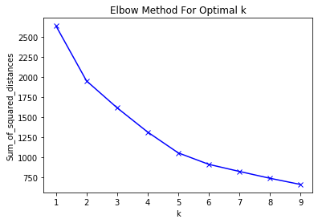

```python
plt.plot(K, Sum_of_squared_distances, 'bx-')
plt.xlabel('k')
plt.ylabel('Sum_of_squared_distances')
plt.title('Elbow Method For Optimal k')
plt.show()
```

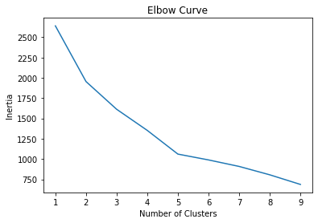

```python
num_clusters = 10
kmeans_tests = [KMeans(n_clusters=i, init='random', n_init=10) for i in range(1, num_clusters)]

score = [kmeans_tests[i].fit(x_standard).inertia_ for i in range(len(kmeans_tests))]

# Plot the curve
plt.plot(range(1, num_clusters),score)
plt.xlabel('Number of Clusters')
plt.ylabel('Inertia')
plt.title('Elbow Curve')
plt.show()
```

The elbow method is a heuristic method to determine the number of clusters. We pick the elbow of the curve as the number of clusters to use. The elbow (or knee) of a curve is a point where the curve visibly bends. It seems to me that the curve bends at k = 5.

```python
kmeans = KMeans(init='random', n_clusters=5)
kmeans.fit(x_standard)
clusters =  kmeans.predict(x_standard)
x_scaled_clustered = pd.DataFrame(x_standard, columns=x.columns, index=x.index)
x_scaled_clustered['cluster'] = clusters
x_scaled_clustered.head(4)
```

|  | Fresh | Milk | Grocery | Frozen | Detergents_Paper | Delicassen | cluster |
| --- | --- | --- | --- | --- | --- | --- | --- |
| 0 | 0.052933 | 0.523568 | -0.041115 | -0.589367 | -0.043569 | -0.066339 | 3 |
| 1 | -0.391302 | 0.544458 | 0.170318 | -0.270136 | 0.086407 | 0.089151 | 2 |
| 2 | -0.447029 | 0.408538 | -0.028157 | -0.137536 | 0.133232 | 2.243293 | 2 |
| 3 | 0.100111 | -0.624020 | -0.392977 | 0.687144 | -0.498588 | 0.093411 | 3 |

```python
plt.rcParams["figure.figsize"]=(15,10)
x_clustered = pd.DataFrame(x_standard, index=x.index, columns=x.columns)
x_clustered["cluster"] = clusters
```

```python
x_clustered.head()
```

|  | Fresh | Milk | Grocery | Frozen | Detergents_Paper | Delicassen | cluster |
| --- | --- | --- | --- | --- | --- | --- | --- |
| 0 | 0.052933 | 0.523568 | -0.041115 | -0.589367 | -0.043569 | -0.066339 | 3 |
| 1 | -0.391302 | 0.544458 | 0.170318 | -0.270136 | 0.086407 | 0.089151 | 2 |
| 2 | -0.447029 | 0.408538 | -0.028157 | -0.137536 | 0.133232 | 2.243293 | 2 |
| 3 | 0.100111 | -0.624020 | -0.392977 | 0.687144 | -0.498588 | 0.093411 | 3 |
| 4 | 0.840239 | -0.052396 | -0.079356 | 0.173859 | -0.231918 | 1.299347 | 0 |

```python
x_clustered.describe()
```

|  | Fresh | Milk | Grocery | Frozen | Detergents_Paper | Delicassen | cluster |
| --- | --- | --- | --- | --- | --- | --- | --- |
| count | 4.400000e+02 | 4.400000e+02 | 4.400000e+02 | 4.400000e+02 | 4.400000e+02 | 4.400000e+02 | 440.000000 |
| mean | -2.422305e-17 | -1.589638e-17 | -6.030530e-17 | 1.135455e-17 | -1.917658e-17 | -8.276208e-17 | 2.450000 |
| std | 1.001138e+00 | 1.001138e+00 | 1.001138e+00 | 1.001138e+00 | 1.001138e+00 | 1.001138e+00 | 0.999886 |
| min | -9.496831e-01 | -7.787951e-01 | -8.373344e-01 | -6.283430e-01 | -6.044165e-01 | -5.402644e-01 | 0.000000 |
| 25% | -7.023339e-01 | -5.783063e-01 | -6.108364e-01 | -4.804306e-01 | -5.511349e-01 | -3.964005e-01 | 2.000000 |
| 50% | -2.767602e-01 | -2.942580e-01 | -3.366684e-01 | -3.188045e-01 | -4.336004e-01 | -1.985766e-01 | 3.000000 |
| 75% | 3.905226e-01 | 1.890921e-01 | 2.849105e-01 | 9.946441e-02 | 2.184822e-01 | 1.048598e-01 | 3.000000 |
| max | 7.927738e+00 | 9.183650e+00 | 8.936528e+00 | 1.191900e+01 | 7.967672e+00 | 1.647845e+01 | 4.000000 |

```python
x_clustered_0 = pd.DataFrame(x_clustered.loc[x_clustered['cluster']== 0])
x_clustered_1 = pd.DataFrame(x_clustered.loc[x_clustered['cluster']== 1])
x_clustered_2 = pd.DataFrame(x_clustered.loc[x_clustered['cluster']== 2])
x_clustered_3 = pd.DataFrame(x_clustered.loc[x_clustered['cluster']== 3])
x_clustered_4 = pd.DataFrame(x_clustered.loc[x_clustered['cluster']== 4])
```

```python
x_clustered_0.head(10)
```

|  | Fresh | Milk | Grocery | Frozen | Detergents_Paper | Delicassen | cluster |
| --- | --- | --- | --- | --- | --- | --- | --- |
| 4 | 0.840239 | -0.052396 | -0.079356 | 0.173859 | -0.231918 | 1.299347 | 0 |
| 22 | 1.525828 | -0.526217 | -0.366851 | 1.306634 | -0.105092 | 0.997242 | 0 |
| 29 | 2.460843 | -0.501394 | -0.562798 | -0.386033 | -0.372602 | -0.249164 | 0 |
| 33 | 1.403370 | -0.137041 | -0.065872 | 0.630640 | -0.529245 | -0.156864 | 0 |
| 36 | 1.421260 | -0.194556 | -0.265822 | -0.276941 | -0.424046 | 1.100902 | 0 |
| 39 | 3.495518 | -0.710971 | -0.742627 | 1.429129 | -0.560531 | 0.493851 | 0 |
| 40 | 0.951852 | -0.198626 | -0.336510 | 1.327668 | -0.364623 | 1.540392 | 0 |
| 52 | 2.273476 | -0.255056 | -0.218626 | -0.523789 | -0.061837 | -0.087639 | 0 |
| 70 | 0.372415 | -0.509939 | -0.500326 | 1.561317 | -0.580689 | -0.056754 | 0 |
| 73 | 0.625246 | -0.062977 | 0.080246 | 1.043495 | -0.444624 | -0.311289 | 0 |

```python
x_clustered_1.head(10)
```

|  | Fresh | Milk | Grocery | Frozen | Detergents_Paper | Delicassen | cluster |
| --- | --- | --- | --- | --- | --- | --- | --- |
| 183 | 1.966817 | 5.175503 | 1.287217 | 6.9006 | -0.554862 | 16.478447 | 1 |

```python
x_clustered_2.head(10)
```

|  | Fresh | Milk | Grocery | Frozen | Detergents_Paper | Delicassen | cluster |
| --- | --- | --- | --- | --- | --- | --- | --- |
| 1 | -0.391302 | 0.544458 | 0.170318 | -0.270136 | 0.086407 | 0.089151 | 2 |
| 2 | -0.447029 | 0.408538 | -0.028157 | -0.137536 | 0.133232 | 2.243293 | 2 |
| 9 | -0.474497 | 0.718495 | 1.151423 | -0.394488 | 0.954031 | 0.203461 | 2 |
| 10 | -0.683474 | -0.053346 | 0.529133 | 0.273876 | 0.649984 | 0.077791 | 2 |
| 12 | 1.560499 | 0.884800 | 0.400925 | -0.574313 | 0.209873 | 0.499176 | 2 |
| 13 | 0.729576 | 0.055851 | 0.740672 | 0.004757 | 0.803267 | -0.327619 | 2 |
| 14 | 1.001564 | 0.497659 | 0.436111 | -0.572869 | 0.457016 | 0.228311 | 2 |
| 16 | -0.869179 | 0.409623 | 0.439272 | -0.605865 | 0.341529 | -0.157929 | 2 |
| 24 | 0.842773 | 0.539846 | 0.615308 | -0.032363 | 0.336069 | 1.509862 | 2 |
| 28 | -0.624343 | 1.992372 | 1.896865 | -0.394694 | 1.201593 | 1.306802 | 2 |

```python
x_clustered_3.head(10)
```

|  | Fresh | Milk | Grocery | Frozen | Detergents_Paper | Delicassen | cluster |
| --- | --- | --- | --- | --- | --- | --- | --- |
| 0 | 0.052933 | 0.523568 | -0.041115 | -0.589367 | -0.043569 | -0.066339 | 3 |
| 3 | 0.100111 | -0.624020 | -0.392977 | 0.687144 | -0.498588 | 0.093411 | 3 |
| 5 | -0.204806 | 0.334067 | -0.297637 | -0.496155 | -0.228138 | -0.026224 | 3 |
| 6 | 0.009950 | -0.352316 | -0.102849 | -0.534512 | 0.054280 | -0.347854 | 3 |
| 7 | -0.349981 | -0.113981 | 0.155359 | -0.289315 | 0.092286 | 0.369601 | 3 |
| 8 | -0.477901 | -0.291409 | -0.185336 | -0.545854 | -0.244726 | -0.275079 | 3 |
| 11 | 0.090692 | -0.633787 | -0.361162 | -0.340664 | -0.489769 | -0.364894 | 3 |
| 15 | -0.138313 | -0.635143 | -0.435116 | -0.551629 | -0.402629 | -0.395069 | 3 |
| 17 | -0.484788 | 0.048933 | -0.528665 | -0.460479 | -0.527355 | 1.048362 | 3 |
| 18 | 0.522499 | 0.071993 | 0.226258 | -0.178780 | -0.024041 | 0.587926 | 3 |

```python
x_clustered_4.head(10)
```

|  | Fresh | Milk | Grocery | Frozen | Detergents_Paper | Delicassen | cluster |
| --- | --- | --- | --- | --- | --- | --- | --- |
| 23 | 1.137716 | 4.154476 | 1.482005 | 0.429367 | 0.305623 | 5.324340 | 4 |
| 47 | 2.569923 | 6.573905 | 5.016638 | 0.971318 | 4.470300 | 1.753747 | 4 |
| 56 | -0.625531 | 3.268554 | 1.992626 | -0.094023 | 3.119940 | -0.065629 | 4 |
| 61 | 1.895179 | 4.418448 | 5.440874 | 0.037546 | 5.001541 | 0.174706 | 4 |
| 65 | -0.943192 | 2.056805 | 3.990233 | -0.626075 | 4.482899 | -0.036164 | 4 |
| 85 | 0.325870 | 5.480306 | 8.936528 | -0.421915 | 7.967672 | 0.503791 | 4 |
| 86 | 0.864778 | 9.183650 | 2.545492 | -0.429958 | 3.609186 | -0.220764 | 4 |
| 92 | -0.221825 | 2.940284 | 2.537064 | 0.033010 | 3.364773 | 1.279822 | 4 |
| 211 | 0.009396 | 3.056128 | 3.344029 | 0.343167 | 3.470601 | 0.477521 | 4 |
| 251 | -0.464365 | 2.351705 | 2.700564 | 0.757672 | 3.299260 | 1.276627 | 4 |

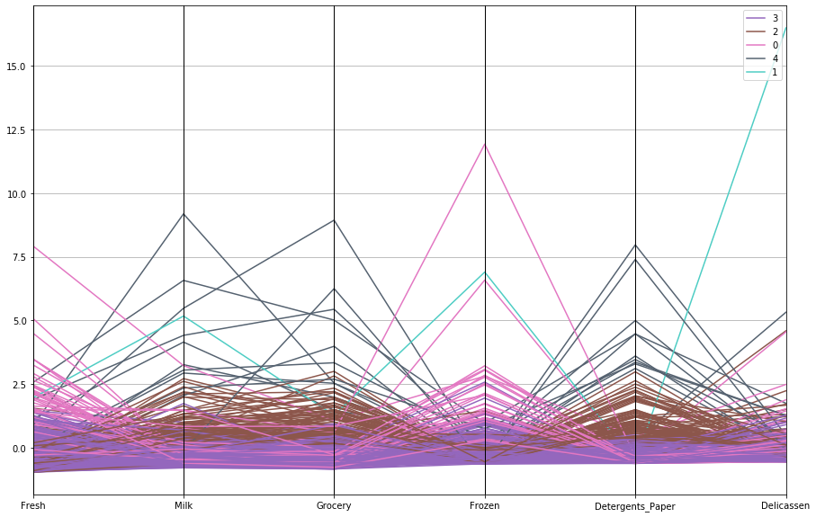

```python
pd.plotting.parallel_coordinates(x_clustered, 'cluster', color=('#9467bd', '#8c564b', '#e377c2','#556270', '#4ECDC4', '#C7F464'))
```

The cluster 4 could be a retail grocery store and the cluster 0 could be a restaurant. Let's make a marketing strategy for cluster 4 that we assume it is a retail grocery store. Based on the graph above, We can see that they have the highest score on milk, grocery and detergents paper so we can give them promotations when they buy these items to stimulate them to buy more, and we can supply them once their inventories of these items are low so that we can ship more items at a time and reduce shipping costs.

#### Carry Out Cluster Analysis using 3 Principal Components

```python
from sklearn.decomposition import PCA
pca = PCA(n_components=3)
pca.fit(x_standard)
x_reduced = pca.transform(x_standard)
```

```python
x_reduceddf = pd.DataFrame(x_reduced, index=x.index, columns=['PC1','PC2','PC3'])
x_reduceddf['cluster'] = clusters
x_reduceddf.head(10)
```

|  | PC1 | PC2 | PC3 | cluster |
| --- | --- | --- | --- | --- |
| 0 | 0.193291 | -0.305100 | -0.140878 | 3 |
| 1 | 0.434420 | -0.328413 | 0.319007 | 2 |
| 2 | 0.811143 | 0.815096 | 1.523416 | 2 |
| 3 | -0.778648 | 0.652754 | 0.163012 | 3 |
| 4 | 0.166287 | 1.271434 | 0.066279 | 0 |
| 5 | -0.156170 | -0.295141 | 0.147612 | 3 |
| 6 | -0.335288 | -0.525003 | -0.303195 | 3 |
| 7 | 0.140586 | -0.230993 | 0.390010 | 3 |
| 8 | -0.517320 | -0.659363 | 0.182510 | 3 |
| 9 | 1.592109 | -0.741011 | 0.210297 | 2 |

```python
reduceddf_0 = pd.DataFrame(x_reduceddf.loc[x_reduceddf['cluster']== 0])
reduceddf_1 = pd.DataFrame(x_reduceddf.loc[x_reduceddf['cluster']== 1])
reduceddf_2 = pd.DataFrame(x_reduceddf.loc[x_reduceddf['cluster']== 2])
reduceddf_3 = pd.DataFrame(x_reduceddf.loc[x_reduceddf['cluster']== 3])
reduceddf_4 = pd.DataFrame(x_reduceddf.loc[x_reduceddf['cluster']== 4])
```

```python
reduceddf_0.head(10)
```

|  | PC1 | PC2 | PC3 | cluster |
| --- | --- | --- | --- | --- |
| 4 | 0.166287 | 1.271434 | 0.066279 | 0 |
| 22 | -0.176695 | 2.143717 | -0.461523 | 0 |
| 29 | -0.779940 | 1.073173 | -2.116771 | 0 |
| 33 | -0.349771 | 1.180595 | -1.038638 | 0 |
| 36 | -0.172137 | 1.267006 | -0.552249 | 0 |
| 39 | -0.779396 | 3.160420 | -2.211695 | 0 |
| 40 | -0.011399 | 2.216469 | 0.344844 | 0 |
| 52 | -0.250713 | 0.862381 | -1.969282 | 0 |
| 70 | -0.804605 | 1.301285 | 0.048806 | 0 |
| 73 | -0.228970 | 0.907521 | -0.436747 | 0 |

```python
reduceddf_1.head(10)
```

|  | PC1 | PC2 | PC3 | cluster |
| --- | --- | --- | --- | --- |
| 183 | 7.79794 | 13.949084 | 8.51513 | 1 |

```python
reduceddf_2.head(10)
```

|  | PC1 | PC2 | PC3 | cluster |
| --- | --- | --- | --- | --- |
| 1 | 0.434420 | -0.328413 | 0.319007 | 2 |
| 2 | 0.811143 | 0.815096 | 1.523416 | 2 |
| 9 | 1.592109 | -0.741011 | 0.210297 | 2 |
| 10 | 0.638086 | -0.401825 | 0.495674 | 2 |
| 12 | 0.991362 | 0.685911 | -1.127060 | 2 |
| 13 | 0.850247 | -0.085692 | -0.949699 | 2 |
| 14 | 0.845044 | 0.154724 | -0.875562 | 2 |
| 16 | 0.557559 | -1.026123 | 0.445792 | 2 |
| 24 | 1.245042 | 1.055660 | 0.020843 | 2 |
| 28 | 3.122092 | -0.330075 | 0.872436 | 2 |

```python
reduceddf_3.head(10)
```

|  | PC1 | PC2 | PC3 | cluster |
| --- | --- | --- | --- | --- |
| 0 | 0.193291 | -0.305100 | -0.140878 | 3 |
| 3 | -0.778648 | 0.652754 | 0.163012 | 3 |
| 5 | -0.156170 | -0.295141 | 0.147612 | 3 |
| 6 | -0.335288 | -0.525003 | -0.303195 | 3 |
| 7 | 0.140586 | -0.230993 | 0.390010 | 3 |
| 8 | -0.517320 | -0.659363 | 0.182510 | 3 |
| 11 | -0.927693 | -0.219287 | -0.258030 | 3 |
| 15 | -0.951585 | -0.495908 | -0.129396 | 3 |
| 17 | -0.352539 | 0.207076 | 0.992945 | 3 |
| 18 | 0.316579 | 0.442066 | -0.165179 | 3 |

```python
reduceddf_4.head(10)
```

|  | PC1 | PC2 | PC3 | cluster |
| --- | --- | --- | --- | --- |
| 23 | 4.685654 | 3.598678 | 1.990551 | 4 |
| 47 | 9.538116 | 1.507637 | -1.750930 | 4 |
| 56 | 4.599756 | -1.236376 | 0.013437 | 4 |
| 61 | 8.430925 | -0.592369 | -2.445199 | 4 |
| 65 | 5.810579 | -2.454932 | -0.283323 | 4 |
| 85 | 12.653002 | -2.715206 | -1.798783 | 4 |
| 86 | 8.420989 | -0.446858 | -1.107632 | 4 |
| 92 | 5.228909 | -0.436535 | 0.300895 | 4 |
| 211 | 5.643833 | -0.664664 | -0.346795 | 4 |
| 251 | 4.992728 | -0.179336 | 0.581155 | 4 |

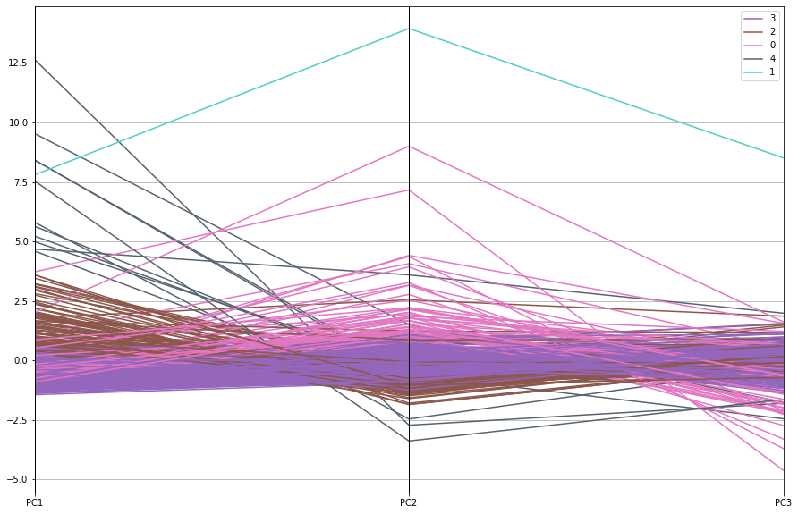

```python
pd.plotting.parallel_coordinates(x_reduceddf, 'cluster', color=('#9467bd', '#8c564b', '#e377c2','#556270', '#4ECDC4', '#C7F464'))
```

The advantage of the first method is that independent variables become more interpretable. The disadvantage is that as the number of dimensions increases, a distance-based similarity measure converges to a constant value between any given examples.This convergence means k-means becomes less effective at distinguishing between examples. This negative consequence of high-dimensional data is called the curse of dimensionality.

The advantage of the second method is that it speed up k-means Clustering by getting rid of correlated variables which don’t contribute in any decision making. The training time of the algorithms reduces significantly with less number of features. The disadvantage of the second method is that if we don’t select the number of Principal Components with care, it may miss some information as compared to the original list of features.